# Hayward Time Series Analysis and Labor Force Classification

## Executive Summary

This analysis seeks two objectives:

- (1) predict production levels for the next four quarters via a time series analysis.
- (2) predict whether a respondent is or is not in the 1975 labor market via machine learning classifciation models trained on a number of economic and demographic features.

**First,** this analysis provides the following predictions for production levels over the next four quarters (in our dataset, 2010 Q3 – 2011 Q2) (powered by an ARIMA model and Facebook's [Prophet](https://facebook.github.io/prophet/)):

[figure not shown]

- *Credit is given to [Jason Brownlee](https://github.com/jbrownlee) for incredible explanations of Time Series ML.*

**Second,** this analysis correctly picked which respondent would be in the workforce with **80.79%** accuracy (74.6% on cross-validation).

The winning model was a Logistic Regression Classification, followed closely by an XGBoost Classification, followed by a Keras Neural Network Classifier (powered by Google’s [TensorFlow](https://www.tensorflow.org)).

From a predictive standpoint, the logistic regression classifier found the following features to be most impactful in predicting whether a respondent (in this study, a heterosexual married woman) was in the 1975 labor force. The following is in order of biggest log-odds impact:

- **federal marginal tax rate facing woman** (proxy for wealth)
  - *increase here = lower labor force likelihood*  
    space
- **husband's hourly wage, 1975**
  - *increase here = lower labor force likelihood*  
    space
- **hours worked by husband, 1975**
  - *increase here = lower labor force likelihood*  
    space
- **number of kids under 6 years old**
  - *increase here = lower labor force likelihood*  
    space
- **age**
  - *increase here = lower labor force likelihood*  
    space
- **years of experience**
  - *increase here = higher labor force likelihood*

From a decion-tree splitting perspective, XGBoost found the following features to be most important (though these numbers have no postive or negative 'sign,' so they do not indicate directionality). The following is in descending order of importantance (most important first):

- years of experience
- number of kids under 6 years old
- number of kids between 6 and 18 years old
- federal marginal tax rate facing woman (proxy for wealth)
- mother's years of schooling
- husband's age
- mother's age
- years of schooling

Credit to God, my Mother, family and friends.

All errors are my own.

Best,  
**George John Jordan Thomas Aquinas Hayward, Optimist**

- Executive Summary
- Selected Data Visualizations
- Key Assumptions and Plan of Attack
  - Part 0. Load in Dependencies
- Problem I: Time Series Forecasting
  - Part 1. ARIMA Model
  - Part 2. Facebook Prophet Model
    - Additional: Combining The Models All on One Graph
- Problem II: Maching Learning Classification
  - Part 3. Exploratory Data Analysis (EDA)
  - Part 4. XGBoost Classification Model
  - Part 5. Logistic Regression Classification Model
  - Part 6. Keras Neural Network Classification Model (with Google's TensorFlow)
- Thank You!

# Selected Data Visualizations

## Time Series

**Time Series Autocorrelation Graph**

[figure not shown]

**ARIMA Prediction**

[figure not shown]

**Facebook Prophet Prediction**

[figure not shown]

**ARIMA vs. FB Prophet Prediction**

[figure not shown]

**ARIMA vs. FB Prophet Prediction Numbers**

[figure not shown]

## Classification

**Feature Pair Plot**

[figure not shown]

**Feature Correlation Matrix**

[figure not shown]

**Logistic Regression Coefficient Interpretation**

[figure not shown]

**XGBoost Feature Importance**

[figure not shown]

**Logistic Regression Confustion Matrix**

[figure not shown]

Back to Top

# Key Assumptions & Plan of Attack

**Time Series**

- This prediction is only for a “1-4 quarter horizon,” which, for this data set, would be 1 year.
- I check for trend (stationary vs. non-stationary) and seasonality (the cyclical nature of the ups and downs in production). I also think about what kind of differencing may be needed.
  - A lot of this can be seen from a plotting of the raw data.
- I use an autocorrelation plot to see what kind of lag we would want to use in models.
- I built an ARIMA model (AutoRegressive Integrated Moving Average):
  - The ARIMA models takes 3 parameters:
    - *p* = number of lag observations needed (the lookback for the autoregression)
    - *d* = the degree of differencing
    - *q* = the size of the moving average window
- I can tune these parameters in a GridSearch-like procedure.
- I also built a Facebook Prophet time series model:
  - From Facebook’s development site:
    - [*“Prophet is a procedure for forecasting time series data based on an additive model where non-linear trends are fit with yearly, weekly, and daily seasonality, plus holiday effects. It works best with time series that have strong seasonal effects and several seasons of historical data. Prophet is robust to missing data and shifts in the trend, and typically handles outliers well.”*](https://facebook.github.io/prophet/)
    - FB Prophet works automatically, and requires fewer parameters.
- Some data scientists prefer ARIMA models because of how customizable they are, but I also wanted to see if the faster FB Prophet model would produce comparable results, which it did.
- I evaluated the ARIMA model on an RMSE (root mean squared error) basis.
- I then plotted the FB Prophet model against the ARIMA model.
- The models are largely in agreement.

**Classification**

- I opted to use three different kinds of regression classification techniques:
  - (1) [Logistic Regression Classifier](https://scikit-learn.org/stable/modules/generated/sklearn.linear_model.LogisticRegression.html)
  - (2) [XGBoost](https://xgboost.readthedocs.io/en/latest/) Classifier
  - (3) [Keras](https://keras.io) Nerual Network Classifier (with Google’s [TensorFlow](https://www.tensorflow.org))
- Features were generally continuous, and the data was generally in great shape.
- Upon future iterations of this analysis, more features could be engineered (sort of like the experience ^ 2 feature).
- I eliminated features that were not predictive because they were not truly independent from the dependent variable:
  - For instance, ‘wage’ and ‘lwage’ must be 0 for those outside the labor force and must be greater than 0 for those in the workforce. As such these features are not really predictive.
  - Similarly, ‘faminc’ and 'nwifeinc' both take into account the wage of respondent (the woman in the household), so it also gives away whether the respondent is or is not in the workforce, I've also eliminated it.
    - In other words, it includes, though not perfectly, the information contained in the ‘wage’ feature, which will taint the predictive power of the model.
  - Finally, 'Repwage' is the wage reported in 1976, but since we're predicting for being in the labor force in 1975, then it should be taken out.
- All models were cross-validated, and the final cross validation accuracies were as follows:
  - Logistic Regression Classification: **74.6%**
  - XGBoost Classification: **71.3%**
  - Keras Neural Network: **71.3%**

Back to Top

# Part 0. Load in Dependencies

- Will load in dependencies for the ARIMA model, Facebook Prophet, XGBoost Classification, Logistic Regression Classification, and Keras Neural Network Classification Model (with Google's TensorFlow). Sk-learn Grid Search will also be loaded, along with Matplotlib.

```python
#for time series work
import altair as alt
alt.renderers.enable('notebook')
import matplotlib.pyplot as plt
%config InlineBackend.figure_format = 'retina'
import pandas as pd
pd.set_option('display.max_columns', None)
from pandas import DataFrame
import numpy as np
from pandas.plotting import autocorrelation_plot
from statsmodels.tsa.arima_model import ARIMA
from math import sqrt
from sklearn.metrics import mean_squared_error
from fbprophet import Prophet
import warnings
warnings.filterwarnings("ignore") #just for the final
#for regression classification work
import seaborn as sns; sns.set()
import missingno as msno
from scipy import stats
from sklearn.linear_model import LinearRegression, LogisticRegression
from sklearn import linear_model
from sklearn.model_selection import train_test_split, cross_val_score, GridSearchCV
from sklearn.preprocessing import StandardScaler
from sklearn.metrics import mean_absolute_error, r2_score, median_absolute_error, \
explained_variance_score, confusion_matrix, accuracy_score, precision_score, recall_score
import xgboost as xgb
from keras.models import Sequential
from keras.layers import Dense
from keras.wrappers.scikit_learn import KerasClassifier
from sklearn.preprocessing import LabelEncoder
from sklearn.model_selection import StratifiedKFold
```

Back to Top

# Part I. Time Series Analysis

- Plan to use ARIMA model and Facebook Prohpet Model.

## A.) Forecasting

Analyze the “production” time series data in the provided file and choose a forecasting model that provides reasonable forecasts at a 1-4 quarter horizon. In addition to including and showing (through code output, visuals, or both) the selected forecasting model, please include descriptions of the following:

- How did you decide on the specific forecasting model? What tests or plots did you use when considering various forecasting approaches?
- How accurate is your model? How did you test its performance?

Back to Top

## 📈 ARIMA Model 📈

```python
#first, we load in the data and set up an ARIMA focused dataframe
df_arima = pd.read_csv('data_A.csv')
#we need to get the string quater naming convention into a datetime friendly format
#I've opted to use January 1 to represent the first quarter, April 1 for the second, July 1 for the third,
#and October 1 for the fourth...this ensures our data points have the correct 3-month interval cadence
df_arima.time = df_arima.time.str.replace(' Q1', '-01-01', regex=False)
df_arima.time = df_arima.time.str.replace(' Q2', '-04-01', regex=False)
df_arima.time = df_arima.time.str.replace(' Q3', '-07-01', regex=False)
df_arima.time = df_arima.time.str.replace(' Q4', '-10-01', regex=False)
df_arima['time'] = pd.to_datetime(df_arima['time'],format='%Y-%m-%d')
df_arima.head()
```

|  | time | production |
| --- | --- | --- |
| 0 | 1956-01-01 | 284 |
| 1 | 1956-04-01 | 213 |
| 2 | 1956-07-01 | 227 |
| 3 | 1956-10-01 | 308 |
| 4 | 1957-01-01 | 262 |

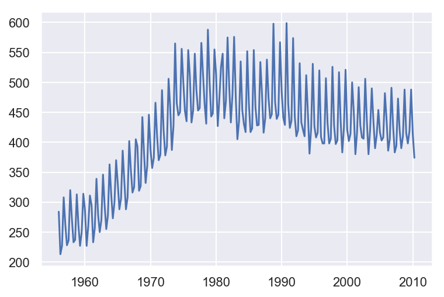

```python
#now plotting the same thing more properly
plt.plot(df_arima.time, df_arima.production)
plt.show()
```

#### 👆🏽Thoughts about this? 👆🏽

- We can see some seasonality as the curve goes up and down with some regularity.
- We do not have a stationary graph, because you can observe a trend from 1960 to 1975, and, again, another trend from 1980 to 2010.

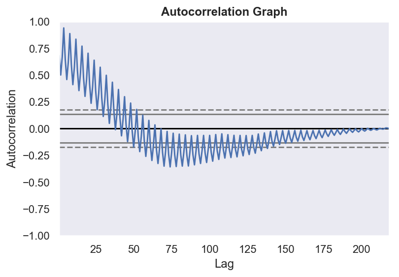

```python
#let's check the autocorrelation to see how many periods back our autoregression should track
autocorrelation_plot(df_arima.production)
plt.title("Autocorrelation Graph", fontweight = 'bold')
plt.savefig('autocorrelation.png',dpi=300, bbox_inches='tight')
plt.show()
```

#### 👆🏽Thoughts about this? 👆🏽

- We see a significant correlation up to around 25 periods, and an extremely high, positive correlation when we look at the first 5 periods.
  - This makes sense to me because there are only 4 quarters in a year, and I would think that the last year (so last 4 periods) would be perhaps the most helpful when thinking about the next four quarters.

```python
X = df_arima.production.values
size = int(len(X) * 0.66)
train, test = X[0:size], X[size:len(X)]
history = [x for x in train]
predictions_arima = []
```

```python
# walk-forward validation
for t in range(len(test)):
    model = ARIMA(history, order=(6,1,1))
    model_fit = model.fit(disp=0)
    output = model_fit.forecast()
    yhat = output[0]
    predictions_arima.append(yhat)
    obs = test[t]
    history.append(obs)
    print('predicted=%f, expected=%f' % (yhat, obs))
```

```
predicted=583.361869, expected=574.000000
predicted=469.884850, expected=443.000000
predicted=422.122631, expected=410.000000
predicted=428.541688, expected=420.000000
predicted=563.170100, expected=532.000000
predicted=439.575125, expected=433.000000
predicted=392.686590, expected=421.000000
predicted=409.343245, expected=410.000000
predicted=532.900785, expected=512.000000
predicted=439.102902, expected=449.000000
predicted=410.926546, expected=381.000000
predicted=415.435590, expected=423.000000
predicted=505.971137, expected=531.000000
predicted=437.016598, expected=426.000000
predicted=397.945416, expected=408.000000
predicted=426.781951, expected=416.000000
predicted=526.411806, expected=520.000000
predicted=441.402115, expected=409.000000
predicted=400.478497, expected=398.000000
predicted=415.083399, expected=398.000000
predicted=509.045246, expected=507.000000
predicted=405.230612, expected=432.000000
predicted=387.455530, expected=398.000000
predicted=406.855965, expected=406.000000
predicted=514.267067, expected=526.000000
predicted=434.329681, expected=428.000000
predicted=407.837323, expected=397.000000
predicted=417.402220, expected=403.000000
predicted=520.466045, expected=517.000000
predicted=431.045554, expected=435.000000
predicted=393.860797, expected=383.000000
predicted=407.807633, expected=424.000000
predicted=514.185726, expected=521.000000
predicted=436.695440, expected=421.000000
predicted=395.823406, expected=402.000000
predicted=423.849517, expected=414.000000
predicted=519.588853, expected=500.000000
predicted=430.609009, expected=451.000000
predicted=390.220780, expected=380.000000
predicted=420.725200, expected=416.000000
```

[output cut: 20 more lines]

```
predicted=481.401355, expected=491.000000
predicted=430.930299, expected=427.000000
predicted=391.689579, expected=383.000000
predicted=409.369527, expected=394.000000
predicted=484.187923, expected=473.000000
predicted=427.008078, expected=420.000000
predicted=375.742417, expected=390.000000
predicted=390.939274, expected=410.000000
predicted=472.662500, expected=488.000000
predicted=428.574274, expected=415.000000
predicted=399.863735, expected=398.000000
predicted=416.609365, expected=419.000000
predicted=485.179996, expected=488.000000
predicted=423.665198, expected=414.000000
predicted=401.149464, expected=374.000000
```

```python
#let's fit the ARIMA model
#the paramters used here are the reult of a grid search I ran in previous analysis
#model = ARIMA(df_arima.production, order=(6,1,1))
#model_fit = model.fit(disp=0)
```

```python
print(model_fit.summary())
```

```
                             ARIMA Model Results
==============================================================================
Dep. Variable:                    D.y   No. Observations:                  216
Model:                 ARIMA(6, 1, 1)   Log Likelihood                -917.664
Method:                       css-mle   S.D. of innovations             16.626
Date:                Sat, 31 Aug 2019   AIC                           1853.327
Time:                        23:30:02   BIC                           1883.705
Sample:                             1   HQIC                          1865.600

==============================================================================
                 coef    std err          z      P>|z|      [0.025      0.975]
------------------------------------------------------------------------------
const          0.7911      0.555      1.425      0.156      -0.297       1.879
ar.L1.D.y     -1.3591      0.142     -9.544      0.000      -1.638      -1.080
ar.L2.D.y     -1.1343      0.160     -7.088      0.000      -1.448      -0.821
ar.L3.D.y     -0.6633      0.169     -3.927      0.000      -0.994      -0.332
ar.L4.D.y      0.3042      0.164      1.860      0.064      -0.016       0.625
ar.L5.D.y      0.6690      0.101      6.592      0.000       0.470       0.868
ar.L6.D.y      0.4357      0.062      6.974      0.000       0.313       0.558
ma.L1.D.y      0.3537      0.157      2.246      0.026       0.045       0.662
                                    Roots
=============================================================================
                  Real          Imaginary           Modulus         Frequency
-----------------------------------------------------------------------------
AR.1            1.3435           -0.0000j            1.3435           -0.0000
AR.2           -0.0020           -1.0062j            1.0062           -0.2503
AR.3           -0.0020           +1.0062j            1.0062            0.2503
AR.4           -1.0252           -0.0000j            1.0252           -0.5000
AR.5           -0.9250           -0.8890j            1.2829           -0.3782
AR.6           -0.9250           +0.8890j            1.2829            0.3782
MA.1           -2.8273           +0.0000j            2.8273            0.5000
-----------------------------------------------------------------------------
```

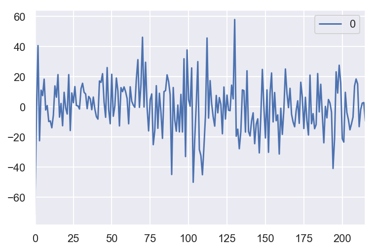

```python
#we check to see if there are any odd pattens in the residuals over the time series
residuals = DataFrame(model_fit.resid)
residuals.plot()
plt.show()
```